# Digital Signal Processing I Project:

Presented by: **Assaad Saneh**  
Under the assistance of: **Dr. Amani Raad**

```python
import numpy as np
from scipy import signal
import matplotlib.pyplot as plt
```

## Presenting the signal:

First of all lets define our signal, the gaussian noise, the sampling frequency of 1Khz, and power spectral desity(PSD), then represnting the noisy signal in both time and frequency domain.

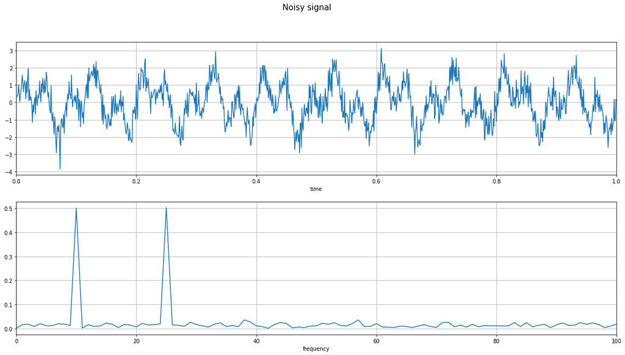

```python
Fs = 1000
t = np.arange(0, 1, 1/Fs)
original_signal = np.sin(2*np.pi*10*t) + np.sin(2*np.pi*25*t)

noise = 0.5 * np.random.normal(0,1,size = len(t))
sig = original_signal + noise

freqs = np.fft.fftfreq(len(t),1/Fs)
fft_sig = np.fft.fft(sig)/len(sig)
fft_noise = np.fft.fft(noise)/len(noise)

fft_sig = np.fft.fftshift(fft_sig)
fft_noise = np.fft.fftshift(fft_noise)
freqs = np.fft.fftshift(freqs)

PSD_sig = fft_sig * np.conj(fft_sig)

fig1, ax1 = plt.subplots(2,1)
fig1.set_figwidth(20)
fig1.set_figheight(10)
fig1.suptitle("Noisy signal", fontsize=15)

ax1[0].set_xlim([0,1])
ax1[1].set_xlim([0,100])
ax1[0].grid()
ax1[1].grid()
ax1[0].set_xlabel("time", fontsize = 10)
ax1[1].set_xlabel("frequency", fontsize = 10)

ax1[0].plot(t, sig)
ax1[1].plot(freqs, np.abs(fft_sig))

plt.savefig('signal.png',bbox_inches='tight',facecolor='white', transparent=False)
plt.show()
```

## Filtering approach:

We are going to use lowpass filters with a cutoff frequecy approximately equal to the frequency specter of our original signal.  
We will use 2 FIR filters and 2 IIR filters then calculate and visualise the resulted error compared to the original signal at the end.

## FIR filters:

We will use the windowing technique to design our filters, we will use 2 windows(Hann and Hamming) and show the filtered results.  
so for both FIR filters, it is clear that they require a higher order filter to give decent results, but also there is a small phase difference after first filtering compared to IIR.

### 1) Hann window:

Starting with Hann window, we see that it gave some decent results, as it is clear visually that the noisy filter is now way smoother and resembles the original 2 frequencies original signal to a high degree.

But that result came for a higher order filter and a relatively higher cutoff as the filter has a slow transition time, also we should note that,despite using higher passing band, the pulse closer to the cutoff frequency (pulse at 25hz) in the frequency domain has shrinked more relative to that far from the cutoff freqency, that could limit the performance of the filter, if the noise is inside the passing band of the filter, the filter wouldn't eliminate the noise while reducing the amplitude of some valuable information located close to the cutoff frequency, plus higher passing band means more noise won't be filtered by the filter.

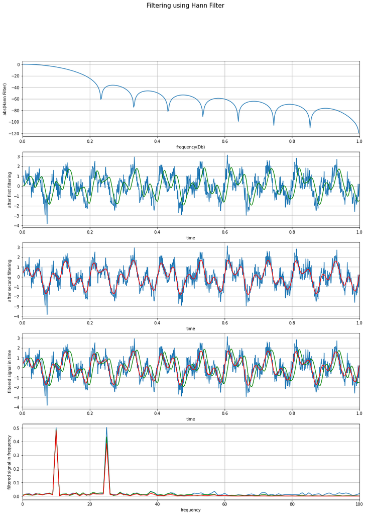

```python
FIR_Hann = signal.firwin(20, 30, window = 'hann' ,fs = Fs)
w_FIR_Hann, h_FIR_Hann = signal.freqz(FIR_Hann)

sig_filt_fir_Hann = signal.lfilter(FIR_Hann,1,sig)
sig_filtfilt_fir_Hann = signal.filtfilt(FIR_Hann,1,sig)
sig_filt_fir_Hann_fft = np.fft.fft(sig_filt_fir_Hann)/len(sig_filt_fir_Hann)
sig_filt_fir_Hann_fft = np.fft.fftshift(sig_filt_fir_Hann_fft)
sig_filtfilt_fir_Hann_fft = np.fft.fft(sig_filtfilt_fir_Hann)/len(sig_filtfilt_fir_Hann)
sig_filtfilt_fir_Hann_fft = np.fft.fftshift(sig_filtfilt_fir_Hann_fft)

fig2, ax2 = plt.subplots(5,1)
fig2.set_figwidth(15)
fig2.set_figheight(20)
fig2.suptitle("Filtering using Hann Filter", fontsize=15)

PSD_Hann = sig_filtfilt_fir_Hann_fft * np.conj(sig_filtfilt_fir_Hann_fft)

ax2[0].set_xlim([0,1])

ax2[1].set_xlim([0,1])
ax2[2].set_xlim([0,1])
ax2[3].set_xlim([0,1])

ax2[0].grid()
ax2[1].grid()
ax2[2].grid()
ax2[3].grid()
ax2[4].grid()

ax2[0].set_xlabel("frequency(Db)", fontsize = 10)
ax2[1].set_xlabel("time", fontsize = 10)
ax2[2].set_xlabel("time", fontsize = 10)
ax2[3].set_xlabel("time", fontsize = 10)
ax2[4].set_xlabel("frequency", fontsize = 10)

ax2[0].set_ylabel("abs(Hann Filter)", fontsize = 10)
ax2[1].set_ylabel("after first filtering", fontsize = 10)
ax2[2].set_ylabel("after second filtering", fontsize = 10)
ax2[3].set_ylabel("filtered signal in time", fontsize = 10)
ax2[4].set_ylabel("filtered signal in frequency", fontsize = 10)

ax2[0].plot(w_FIR_Hann / np.pi, 20 * np.log10(np.abs(h_FIR_Hann / np.abs(h_FIR_Hann).max())))

ax2[1].plot(t, sig)
ax2[1].plot(t, sig_filt_fir_Hann, 'g')

ax2[2].plot(t, sig)
ax2[2].plot(t, sig_filtfilt_fir_Hann, 'r')

ax2[3].plot(t, sig)
ax2[3].plot(t, sig_filt_fir_Hann, 'g')
ax2[3].plot(t, sig_filtfilt_fir_Hann, 'r')

ax2[4].set_xlim([0,100])
ax2[4].plot(freqs, np.abs(fft_sig))
ax2[4].plot(freqs, np.abs(sig_filt_fir_Hann_fft), 'g')
ax2[4].plot(freqs, np.abs(sig_filtfilt_fir_Hann_fft), 'r')

plt.savefig('Hann.png',bbox_inches='tight',facecolor='white', transparent=False)
plt.show()
```

### 2) Hamming window:

It is clear that Hamming shares almost the same advantages of Hann window, but also the same drawbacks, in fact if we want to analyse the results on the same order and cutoff frequency we see that Hamming window performes even worse, especially in terms of reduction in the second pulse(that at 25hz).

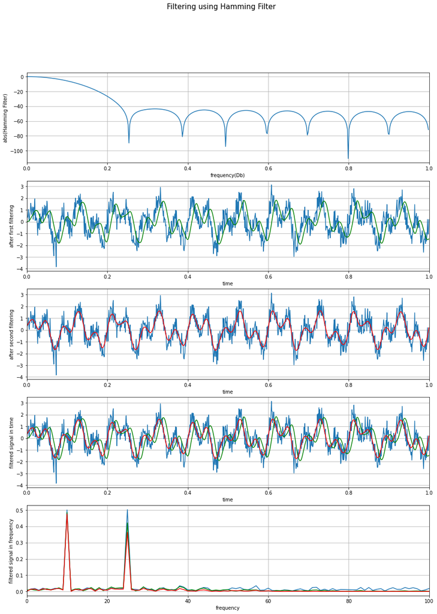

```python
FIR_Hamming = signal.firwin(20, 30, window = 'hamming' ,fs = Fs)
w_FIR_Hamming, h_FIR_Hamming = signal.freqz(FIR_Hamming)

sig_filt_fir_Hamming = signal.lfilter(FIR_Hamming,1,sig)
sig_filtfilt_fir_Hamming = signal.filtfilt(FIR_Hamming,1,sig)
sig_filt_fir_Hamming_fft = np.fft.fft(sig_filt_fir_Hamming)/len(sig_filt_fir_Hamming)
sig_filt_fir_Hamming_fft = np.fft.fftshift(sig_filt_fir_Hamming_fft)
sig_filtfilt_fir_Hamming_fft = np.fft.fft(sig_filtfilt_fir_Hamming)/len(sig_filtfilt_fir_Hamming)
sig_filtfilt_fir_Hamming_fft = np.fft.fftshift(sig_filtfilt_fir_Hamming_fft)

PSD_Hamming = sig_filtfilt_fir_Hamming_fft * np.conj(sig_filtfilt_fir_Hamming_fft)

fig3, ax3 = plt.subplots(5,1)
fig3.set_figwidth(15)
fig3.set_figheight(20)
fig3.suptitle("Filtering using Hamming Filter", fontsize=15)

ax3[0].set_xlim([0,1])

ax3[1].set_xlim([0,1])
ax3[2].set_xlim([0,1])
ax3[3].set_xlim([0,1])

ax3[0].grid()
ax3[1].grid()
ax3[2].grid()
ax3[3].grid()
ax3[4].grid()

ax3[0].set_xlabel("frequency(Db)", fontsize = 10)
ax3[1].set_xlabel("time", fontsize = 10)
ax3[2].set_xlabel("time", fontsize = 10)
ax3[3].set_xlabel("time", fontsize = 10)
ax3[4].set_xlabel("frequency", fontsize = 10)

ax3[0].set_ylabel("abs(Hamming Filter)", fontsize = 10)
ax3[1].set_ylabel("after first filtering", fontsize = 10)
ax3[2].set_ylabel("after second filtering", fontsize = 10)
ax3[3].set_ylabel("filtered signal in time", fontsize = 10)
ax3[4].set_ylabel("filtered signal in frequency", fontsize = 10)

ax3[0].plot(w_FIR_Hamming / np.pi, 20 * np.log10(np.abs(h_FIR_Hamming / np.abs(h_FIR_Hamming).max())))

ax3[1].plot(t, sig)
ax3[1].plot(t, sig_filt_fir_Hamming, 'g')

ax3[2].plot(t, sig)
ax3[2].plot(t, sig_filtfilt_fir_Hamming, 'r')

ax3[3].plot(t, sig)
ax3[3].plot(t, sig_filt_fir_Hamming, 'g')
ax3[3].plot(t, sig_filtfilt_fir_Hamming, 'r')

ax3[4].set_xlim([0,100])
ax3[4].plot(freqs, np.abs(fft_sig))
ax3[4].plot(freqs, np.abs(sig_filt_fir_Hamming_fft), 'g')
ax3[4].plot(freqs, np.abs(sig_filtfilt_fir_Hamming_fft), 'r')

plt.savefig('Hamming.png',bbox_inches='tight',facecolor='white', transparent=False)
plt.show()
```

## IIR Fiters:

We will use Cheby1 and elliptical filters as IIR filters to test their performance.

First of all, unlike FIR filters, we are no longer in need of high order filters to get good results, order 4 IIR filter even gives better output than order 20 FIR filter, so that reduces the complexity of out system, but after the first filtering the phase difference between unfiltered and filtered signals are signifcant, this is remarkable but minor inconvenient, but the bigger drawback is the limited capability of such filters to eliminate noise in the passing band, in fact the noise even get amplified after the first filtering.

Despite that, IIR filters performed way better that FIR filter.

### 1) Chebychev type I:

We can see that the Cheby1 filter performed really good especially compared to previous filters, but it still present the classic drawbacks mentioned above.  
Also we should note that Cheby1 has faster transition time so we can further limit the passing band of the filter and gain more selectivity, but it present some oscillation in the passing band.

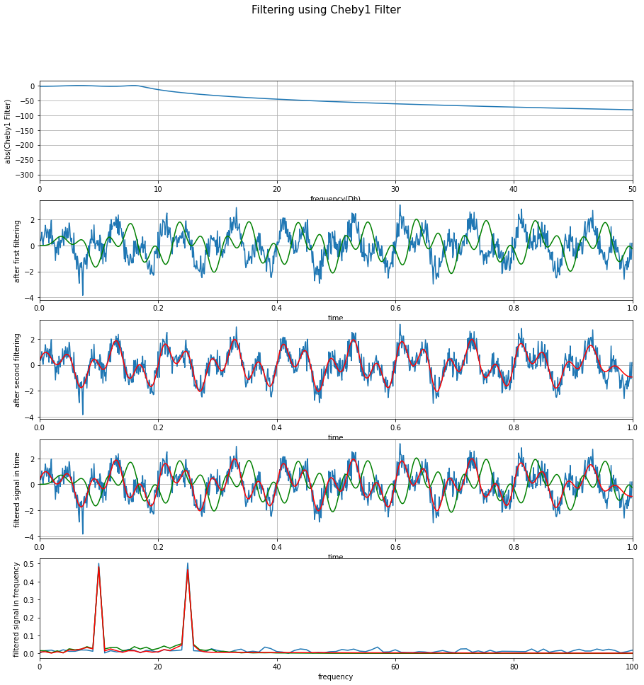

```python
b, a = signal.iirfilter(4, 27, rp=3, rs=40, btype='lowpass', ftype='cheby1', fs = Fs)
w, h = signal.freqz(b, a, fs=Fs)

sig_filt_iir1 = signal.lfilter(b,a,sig)
sig_filtfilt_iir1 = signal.filtfilt(b,a,sig)

sig_filt_iir1_fft = np.fft.fft(sig_filt_iir1)/len(sig_filt_iir1)
sig_filt_iir1_fft = np.fft.fftshift(sig_filt_iir1_fft)
sig_filtfilt_iir1_fft = np.fft.fft(sig_filtfilt_iir1)/len(sig_filtfilt_iir1)
sig_filtfilt_iir1_fft = np.fft.fftshift(sig_filtfilt_iir1_fft)

PSD_iir1 = sig_filtfilt_iir1_fft * np.conj(sig_filtfilt_iir1_fft)

fig4, ax4 = plt.subplots(5,1)
fig4.set_figwidth(15)
fig4.set_figheight(15)
fig4.suptitle("Filtering using Cheby1 Filter", fontsize=15)

ax4[0].set_xlim([0,50])
ax4[1].set_xlim([0,1])
ax4[2].set_xlim([0,1])
ax4[3].set_xlim([0,1])

ax4[0].grid()
ax4[1].grid()
ax4[2].grid()
ax4[3].grid()

ax4[0].set_xlabel("frequency(Db)", fontsize = 10)
ax4[1].set_xlabel("time", fontsize = 10)
ax4[2].set_xlabel("time", fontsize = 10)
ax4[3].set_xlabel("time", fontsize = 10)
ax4[4].set_xlabel("frequency", fontsize = 10)

ax4[0].set_ylabel("abs(Cheby1 Filter)", fontsize = 10)
ax4[1].set_ylabel("after first filtering", fontsize = 10)
ax4[2].set_ylabel("after second filtering", fontsize = 10)
ax4[3].set_ylabel("filtered signal in time", fontsize = 10)
ax4[4].set_ylabel("filtered signal in frequency", fontsize = 10)

ax4[0].plot(w/np.pi, 20 * np.log10(np.abs(h / np.abs(h).max())))

ax4[1].plot(t, sig)
ax4[1].plot(t, sig_filt_iir1, 'g')

ax4[2].plot(t, sig)
ax4[2].plot(t, sig_filtfilt_iir1, 'r')

ax4[3].plot(t, sig)
ax4[3].plot(t, sig_filt_iir1, 'g')
ax4[3].plot(t, sig_filtfilt_iir1, 'r')

ax4[4].set_xlim([0,100])
ax4[4].plot(freqs, np.abs(fft_sig))
ax4[4].plot(freqs, np.abs(sig_filt_iir1_fft), 'g')
ax4[4].plot(freqs, np.abs(sig_filtfilt_iir1_fft), 'r')

plt.savefig('Cheby1.png',bbox_inches='tight',facecolor='white', transparent=False)
plt.show()
```

### 2) Elliptical filter:

Elliptical filter gave the fastest transitioning time, thus reducing the biggest amount of noise, but because of the oscillation in both passing and blocking band, the main signal we are interested in is reduced while some noisy outside the passing band may seek it's way into the filtered signal because of the oscillation in the stop band.

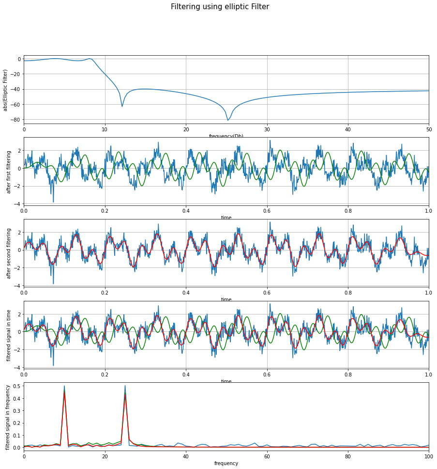

```python
b2, a2 = signal.iirfilter(4, 27, rp=3, rs=40, btype='lowpass', ftype='ellip', fs = Fs)
w2, h2 = signal.freqz(b2, a2, fs=Fs)

sig_filt_iir2 = signal.lfilter(b2,a2,sig)
sig_filtfilt_iir2 = signal.filtfilt(b2,a2,sig)

sig_filt_iir2_fft = np.fft.fft(sig_filt_iir2)/len(sig_filt_iir2)
sig_filt_iir2_fft = np.fft.fftshift(sig_filt_iir2_fft)
sig_filtfilt_iir2_fft = np.fft.fft(sig_filtfilt_iir2)/len(sig_filtfilt_iir2)
sig_filtfilt_iir2_fft = np.fft.fftshift(sig_filtfilt_iir2_fft)

PSD_iir2 = sig_filtfilt_iir2_fft * np.conj(sig_filtfilt_iir2_fft)

fig5, ax5 = plt.subplots(5,1)
fig5.set_figwidth(15)
fig5.set_figheight(15)
fig5.suptitle("Filtering using elliptic Filter", fontsize=15)

ax5[0].set_xlim([0,50])
ax5[1].set_xlim([0,1])
ax5[2].set_xlim([0,1])
ax5[3].set_xlim([0,1])

ax5[0].grid()
ax5[1].grid()
ax5[2].grid()
ax5[3].grid()

ax5[0].set_xlabel("frequency(Db)", fontsize = 10)
ax5[1].set_xlabel("time", fontsize = 10)
ax5[2].set_xlabel("time", fontsize = 10)
ax5[3].set_xlabel("time", fontsize = 10)
ax5[4].set_xlabel("frequency", fontsize = 10)

ax5[0].set_ylabel("abs(Elliptic Filter)", fontsize = 10)
ax5[1].set_ylabel("after first filtering", fontsize = 10)
ax5[2].set_ylabel("after second filtering", fontsize = 10)
ax5[3].set_ylabel("filtered signal in time", fontsize = 10)
ax5[4].set_ylabel("filtered signal in frequency", fontsize = 10)

ax5[0].plot(w/np.pi, 20 * np.log10(np.abs(h2 / np.abs(h2).max())))

ax5[1].plot(t, sig)
ax5[1].plot(t, sig_filt_iir2, 'g')

ax5[2].plot(t, sig)
ax5[2].plot(t, sig_filtfilt_iir2, 'r')

ax5[3].plot(t, sig)
ax5[3].plot(t, sig_filt_iir2, 'g')
ax5[3].plot(t, sig_filtfilt_iir2, 'r')

ax5[4].set_xlim([0,100])
ax5[4].plot(freqs, np.abs(fft_sig))
ax5[4].plot(freqs, np.abs(sig_filt_iir2_fft), 'g')
ax5[4].plot(freqs, np.abs(sig_filtfilt_iir2_fft), 'r')

plt.savefig('Ellip.png',bbox_inches='tight',facecolor='white', transparent=False)
plt.show()
```

# Error assesment:

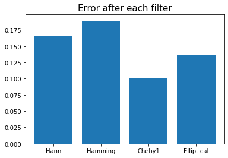

```python
err_fir_Hann = np.sqrt(np.square(original_signal - sig_filtfilt_fir_Hann)).mean(axis = 0)
err_fir_Hamming = np.sqrt(np.square(original_signal - sig_filtfilt_fir_Hamming)).mean(axis = 0)
err_iir1 = np.sqrt(np.square(original_signal - sig_filtfilt_iir1)).mean(axis = 0)
err_iir2 = np.sqrt(np.square(original_signal - sig_filtfilt_iir2)).mean(axis = 0)

plt.title("Error after each filter", fontsize=15)
plt.bar(['Hann','Hamming','Cheby1','Elliptical'],[err_fir_Hann, err_fir_Hamming, err_iir1, err_iir2])

plt.savefig('error.png',bbox_inches='tight',facecolor='white', transparent=False)
plt.show()
```

## PSD anaysis:

Here we see the noise in the power spectral density left after filtering by all the 4 filters.

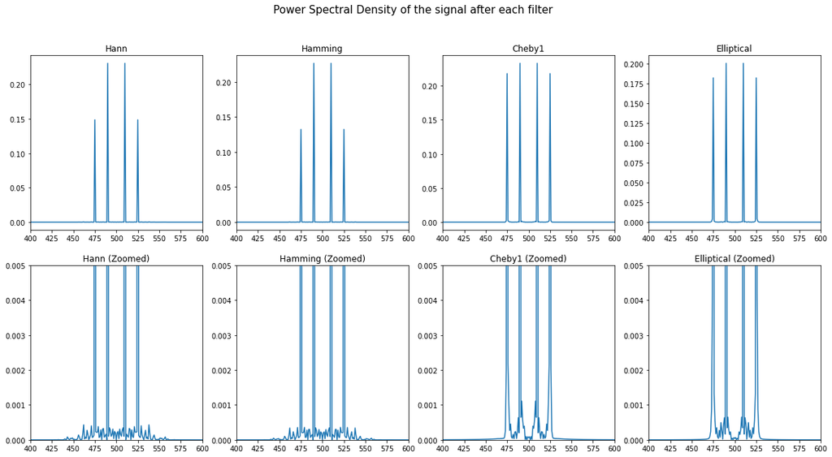

```python
PSD_list = [PSD_Hann, PSD_Hamming, PSD_iir1, PSD_iir2]
PSD_names = ['Hann','Hamming','Cheby1','Elliptical']

fig6, ax6 = plt.subplots(2,4)

fig6.set_figwidth(20)
fig6.set_figheight(10)
fig6.suptitle("Power Spectral Density of the signal after each filter", fontsize=15)

[ax6[k,i].set_xlim([400,600]) for i in range(4) for k in [0,1]]
[ax6[1,i].set_ylim([0,0.005]) for i in range(4)]
[ax6[k,i].plot(np.abs(PSD_list[i])) for i in range(4) for k in [0,1]]
[ax6[0,i].set_title(PSD_names[i]) for i in range(4)]
[ax6[1,i].set_title(PSD_names[i] + " (Zoomed)") for i in range(4)]

plt.savefig('PSD_noise.png',bbox_inches='tight',facecolor='white', transparent=False)
plt.show()
```

# Bonus: Eliminating white noise digitally:

We just use the fft to obtain the spectral representaion and eliminate all noise below a certain threshold amplitude  
(Credit: Professor Steve Brunton, [Youtube video here](https://www.youtube.com/watch?v=s2K1JfNR7Sc&t=438s)).

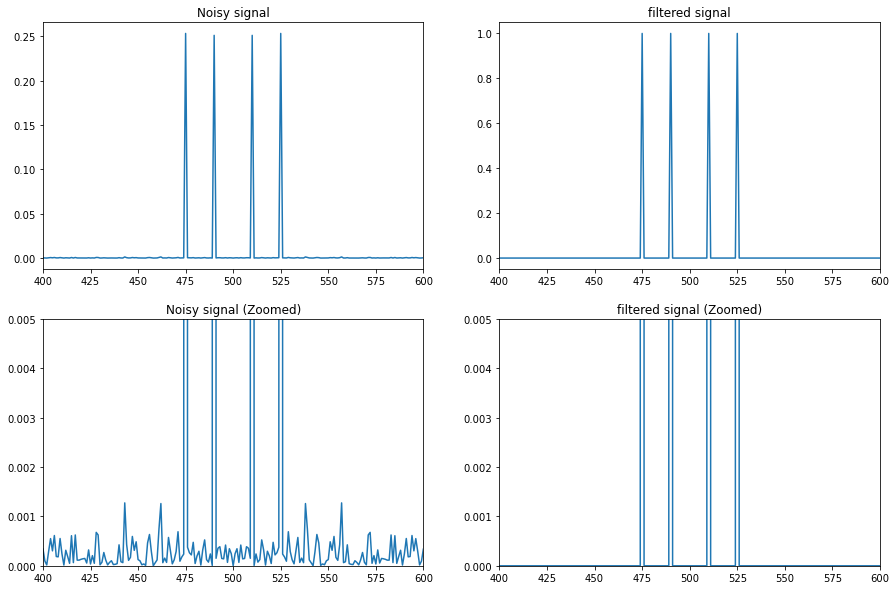

```python
fig7, ax7 = plt.subplots(2,2)

fig7.set_figwidth(15)
fig7.set_figheight(10)

ax7[0,0].set_xlim([400,600])
ax7[0,1].set_xlim([400,600])
ax7[1,0].set_xlim([400,600])
ax7[1,1].set_xlim([400,600])
ax7[1,0].set_ylim([0,0.005])
ax7[1,1].set_ylim([0,0.005])

ax7[0,0].plot(abs(PSD_sig))
ax7[1,0].plot(abs(PSD_sig))
ax7[0,1].plot(abs(PSD_sig) > 0.1)
ax7[1,1].plot(abs(PSD_sig) > 0.1)

ax7[0,0].set_title('Noisy signal')
ax7[0,1].set_title('filtered signal')
ax7[1,0].set_title('Noisy signal (Zoomed)')
ax7[1,1].set_title('filtered signal (Zoomed)')

plt.savefig('PSD_ellimination.png',bbox_inches='tight',facecolor='white', transparent=False)
plt.show()
```